# Class_Nov3

Basanta Khakurel

2022-11-10

# Camera Trap Data Analysis and NMDS

## Camera Trap Data Analysis

Look at some National Camera Traps to identify different organisms occuring in those regions. Few different habitats in Florida

Install `mapview` package

```r
#remotes::install_github("r-spatial/mapview")
```

Load required packages

```r
library(tidyverse)
library(googlesheets4)
library(iNEXT)
library(fields)
library(sf)
```

```r
library(mapview)
```

Download the data

```r
gs4_deauth() #we're pulling some data that are public. So not using password.
cam <- read_sheet("https://docs.google.com/spreadsheets/d/1esrbC-QqoufjlDHXtIYtDcsXovC_x6o6Z4JfBPKvg3s/edit?usp=sharing")
```

```
## ✔ Reading from "FL_cameras".
```

```
## ✔ Range 'FL_cameras'.
```

Lets look at the data

```r
dim(cam)
```

```
## [1] 8683   18
```

```r
names(cam)
```

```
##  [1] "Project"                   "Subproject"
##  [3] "Treatment"                 "Deployment Name"
##  [5] "ID Type"                   "Deployment ID"
##  [7] "Sequence ID"               "Begin Time"
##  [9] "End Time"                  "Species Name"
## [11] "Common Name"               "Age"
## [13] "Sex"                       "Individually Identifiable"
## [15] "Count"                     "Actual Lat"
## [17] "Actual Lon"                "Fuzzed"
```

```r
cam
```

```
## # A tibble: 8,683 × 18
##    Project       Subpr…¹ Treat…² Deplo…³ ID Ty…⁴ Deplo…⁵ Seque…⁶ Begin…⁷ End T…⁸
##    <chr>         <chr>   <lgl>   <chr>   <chr>   <list>  <chr>   <list>  <list>
##  1 Okaloosa S.C… Florid… NA      SQ66_C… Resear… <dbl>   4355s1  <dttm>  <dttm>
##  2 Okaloosa S.C… Florid… NA      SQ66_C… Resear… <dbl>   4355s2  <dttm>  <dttm>
##  3 Okaloosa S.C… Florid… NA      SQ66_C… Resear… <dbl>   4355s3  <dttm>  <dttm>
##  4 Okaloosa S.C… Florid… NA      SQ66_C… Resear… <dbl>   4355s4  <dttm>  <dttm>
##  5 Okaloosa S.C… Florid… NA      SQ122_… Resear… <dbl>   4358s1  <dttm>  <dttm>
##  6 Okaloosa S.C… Florid… NA      SQ122_… Resear… <dbl>   4358s10 <dttm>  <dttm>
##  7 Okaloosa S.C… Florid… NA      SQ122_… Resear… <dbl>   4358s11 <dttm>  <dttm>
##  8 Okaloosa S.C… Florid… NA      SQ122_… Resear… <dbl>   4358s12 <dttm>  <dttm>
##  9 Okaloosa S.C… Florid… NA      SQ122_… Resear… <dbl>   4358s2  <dttm>  <dttm>
## 10 Okaloosa S.C… Florid… NA      SQ122_… Resear… <dbl>   4358s3  <dttm>  <dttm>
## # … with 8,673 more rows, 9 more variables: `Species Name` <chr>,
## #   `Common Name` <chr>, Age <chr>, Sex <chr>,
## #   `Individually Identifiable` <chr>, Count <dbl>, `Actual Lat` <dbl>,
## #   `Actual Lon` <dbl>, Fuzzed <lgl>, and abbreviated variable names
## #   ¹Subproject, ²Treatment, ³`Deployment Name`, ⁴`ID Type`, ⁵`Deployment ID`,
## #   ⁶`Sequence ID`, ⁷`Begin Time`, ⁸`End Time`
```

Cleaning up the names

```r
names(cam) <- make.names(names(cam), unique = TRUE) #create good names without spaces

#We need to clean up names and get rid of spaces. These search for spaces in the given column names and replace them with periods
cam$Species.Name <- str_replace_all(cam$Species.Name, " ", ".")
cam$Common.Name <- str_replace_all(cam$Common.Name, " ", ".")
cam$Subproject <- str_replace_all(cam$Subproject, " ", ".")
cam$Subproject <- str_replace_all(cam$Subproject, "/", ".") #there is one subproject name that has a /. Let's just change it to a period for consistency's sake.
```

Summarizing counts and organizing them into subprojects or Forest Types. Sites in Columns and Species in Rows. Gathering and spreading the data. Collapsing the multiple variable data to one variable statistic.

```r
speciesCount <- cam %>%
  select(Common.Name, Count, Subproject) %>%
  group_by(Common.Name, Subproject) %>% #Here I group the data by species and the subproject
  summarize(totalCount = sum(Count)) %>% #This now gives the sum of the count of each species per subproject
  spread(Subproject, totalCount) #Now I need to change the orientation so that species are rows and subprojects are columns. This pivots the table to do that. More explanation here: https://rpubs.com/bradleyboehmke/data_wrangling
speciesCount
```

```
## # A tibble: 40 × 6
## # Groups:   Common.Name [40]
##    Common.Name         Florida.Bottomland.Hard…¹ Flori…² Flori…³ Flori…⁴ Flori…⁵
##    <chr>                                   <dbl>   <dbl>   <dbl>   <dbl>   <dbl>
##  1 American.Black.Bear                        30      NA       1      10      26
##  2 Animal.Not.on.List                         NA       2      NA      NA      NA
##  3 Bobcat                                     20       8       1      11      21
##  4 Calibration.Photos                         10       2      NA      14       6
##  5 Camera.Misfire                            418       1      NA       2     252
##  6 Camera.Trapper                            402      52      29     290     395
##  7 Coyote                                     44      31       8      23      65
##  8 Domestic.Cat                               NA      22      18      NA      NA
##  9 Domestic.Dog                               11      12      37      37      22
## 10 Domestic.Horse                              1      NA      NA      NA      NA
## # … with 30 more rows, and abbreviated variable names
## #   ¹Florida.Bottomland.Hardwood.Forest, ²Florida.Coastal.Forest.Dunes,
## #   ³Florida.Developed, ⁴Florida.Upland.Hardwood.Forest,
## #   ⁵Florida.Upland.Pine.Sandhill
```

### Abundance for each subproject.

```r
abundance <- cam %>%
  group_by(Subproject) %>%
  filter(!is.na(Species.Name)) %>%  #filter out any NAs in the species name, just in case
  summarize(SpeciesAbundance = length(unique(Species.Name)))
abundance
```

```
## # A tibble: 5 × 2
##   Subproject                         SpeciesAbundance
##   <chr>                                         <int>
## 1 Florida.Bottomland.Hardwood.Forest               33
## 2 Florida.Coastal.Forest.Dunes                     20
## 3 Florida.Developed                                25
## 4 Florida.Upland.Hardwood.Forest                   29
## 5 Florida.Upland.Pine.Sandhill                     28
```

This metric has some shortcomings too. Could be one species is really dominating with just a minority of other taxa in there. Doesn’t tell us how much overlap is there between the sites.

## Species Richness

How much of different species are there in any particular region/sub-project.

Transform the data to match nicely with iNEXT

```r
speciesCount[is.na(speciesCount)]=0 #This turns the NAs that come from summing 0's into real 0's for analysis
camDiv <- as.data.frame(speciesCount) #Since iNext wants a data frame, turn the tibble into one
rownames(camDiv) <- camDiv$Common.Name #iNext also wants the species ID as row names.
camDiv <- camDiv[2:6] #Now we can get rid of the species name since it's already in our row name.
```

Calculate Species Richness and Plot it.

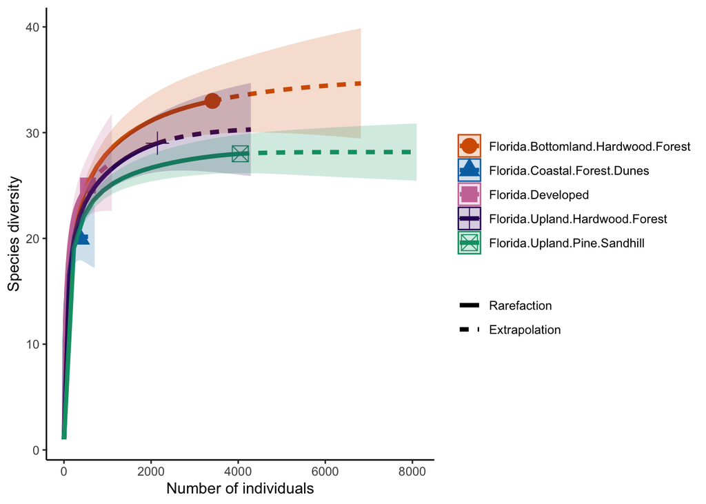

```r
richness <- iNEXT(camDiv, q=0, datatype = "abundance") #This calculates hill numbers for the number of observations we have. q changes the expected relationship. 0 will give Richness
ggiNEXT(richness) + theme(legend.position = "right") + theme_classic()
```

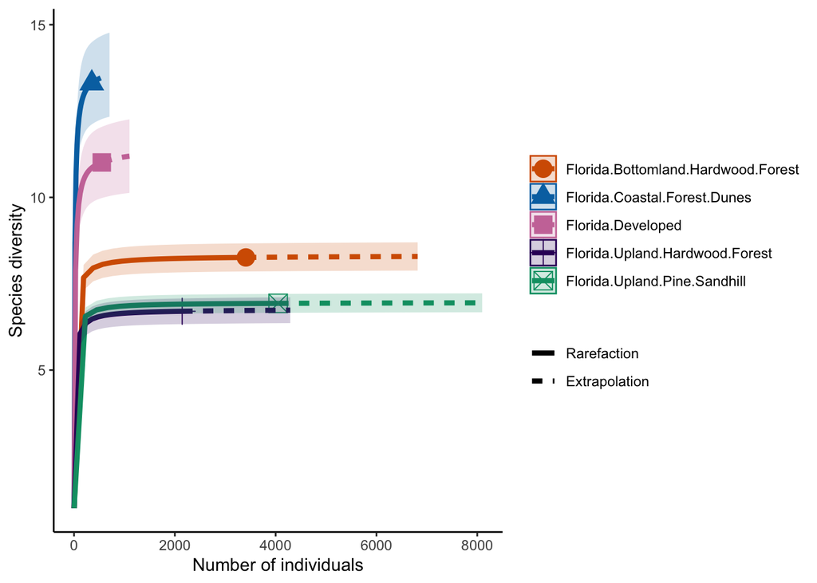

```r
diversity_Shan <- iNEXT(camDiv, q=1, datatype = "abundance") #This calculates hill numbers for the number of observations we have. q changes the expected relationship. q=1 gives the Shannon Diversity index.
ggiNEXT(diversity_Shan)+
  theme(legend.position = "right")+
  theme_classic()
```

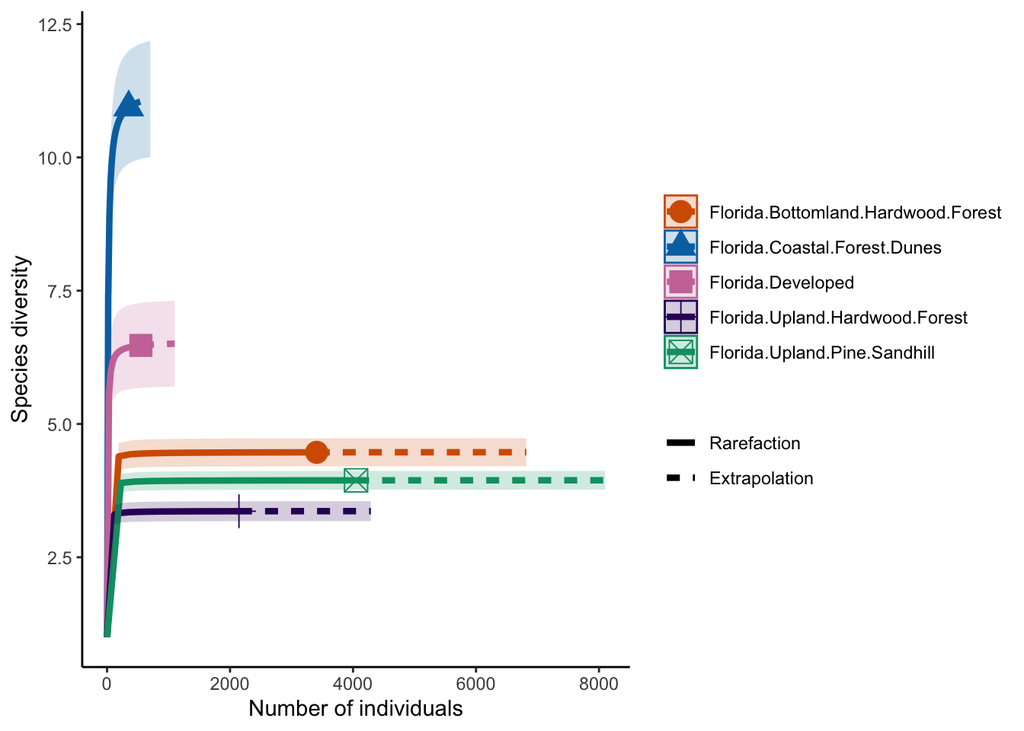

```r
diversity_Simps <- iNEXT(camDiv, q=2, datatype = "abundance") #This calculates hill numbers for the number of observations we have. q changes the expected relationship. q=2 gives the Simpsons Diversity index.
ggiNEXT(diversity_Simps)+
  theme(legend.position = "right")+
  theme_classic()
```

Looking at each diversity calculation within each site

```r
allDiversity <- iNEXT(camDiv, q=c(0, 1, 2), datatype="abundance", endpoint=7000)
```

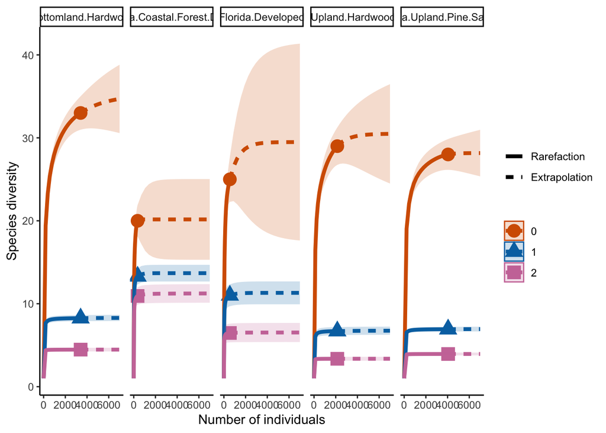

```r
ggiNEXT(allDiversity, type=1, facet.var="Assemblage")+
  theme_classic()
```

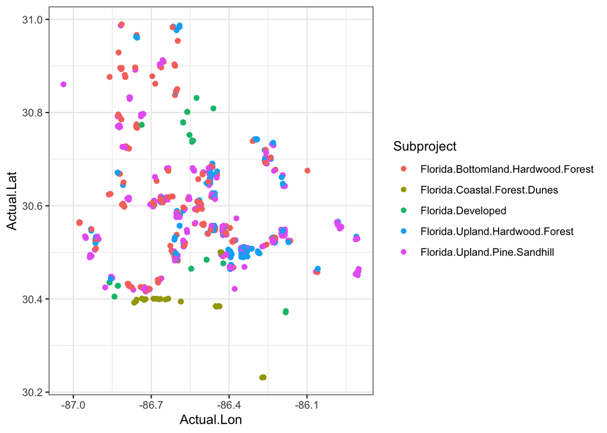

```r
ggplot(cam, aes(x=Actual.Lon, y=Actual.Lat, color = Subproject))+
  geom_point()+
  theme_bw()
```

Location of each camera scaled by numbers of animals and colored by the habitat

```r
deployCount <- cam %>% dplyr::select(Common.Name, Count, Deployment.ID, Actual.Lon, Actual.Lat, Subproject) %>%
  group_by(Deployment.ID, Actual.Lon, Actual.Lat, Subproject) %>%
  summarize(totalCount = sum(Count))
```

[output not shown]

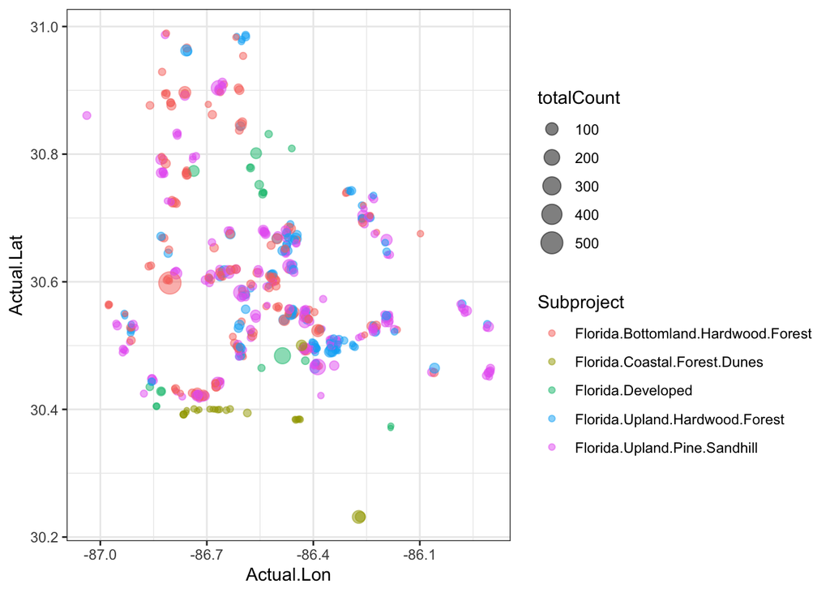

```r
ggplot(deployCount)+
  geom_point(aes(x=Actual.Lon, y=Actual.Lat, size=totalCount, color=Subproject), alpha=0.5)+
  theme_bw()
```

Making a Zoomable and Interactive map.

```r
library(sf)
library(mapview)

#Transform these objects into something that can be plotted with the package {sf}
deployCount_sf <- deployCount %>% st_as_sf(coords = c("Actual.Lon", "Actual.Lat"), crs=4326)

camMap <- mapview(deployCount_sf, zcol="Subproject", cex="totalCount", layer.name = "Habitat Type")
camMap
```

[interactive chart not shown]

# NMDS

```r
library(vegan)
```

Vegan will expect the species names to be the columns and the site to be the row:

```r
speciesCount <- cam %>%
  select(Common.Name, Count, Subproject) %>%
  group_by(Common.Name, Subproject) %>% #Here I group the data by species and the subproject
  summarize(totalCount = sum(Count)) %>% #This now gives the sum of the count of each species per subproject
  spread(Common.Name, totalCount, fill = 0)
speciesMatrix <- data.matrix(speciesCount, rownames.force = unique(cam$Subproject))
```

Perform NMDS

```r
cam_trap_NMDS <- metaMDS(speciesMatrix)
```

```
## Square root transformation
## Wisconsin double standardization
## *** Best solution was not repeated -- monoMDS stopping criteria:
##     17: stress < smin
##      1: stress ratio > sratmax
##      2: scale factor of the gradient < sfgrmin
```

Create a stressplot.

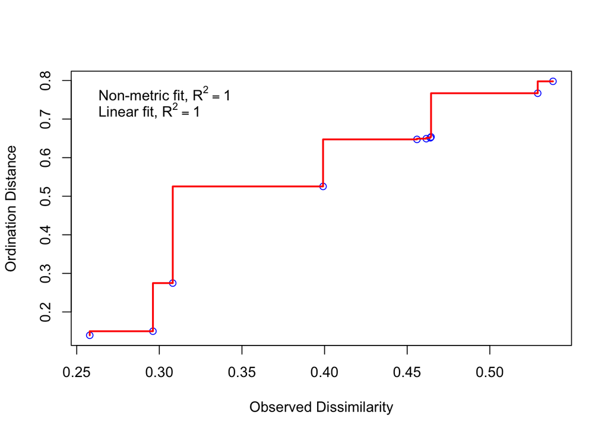

```r
stressplot(cam_trap_NMDS)
```

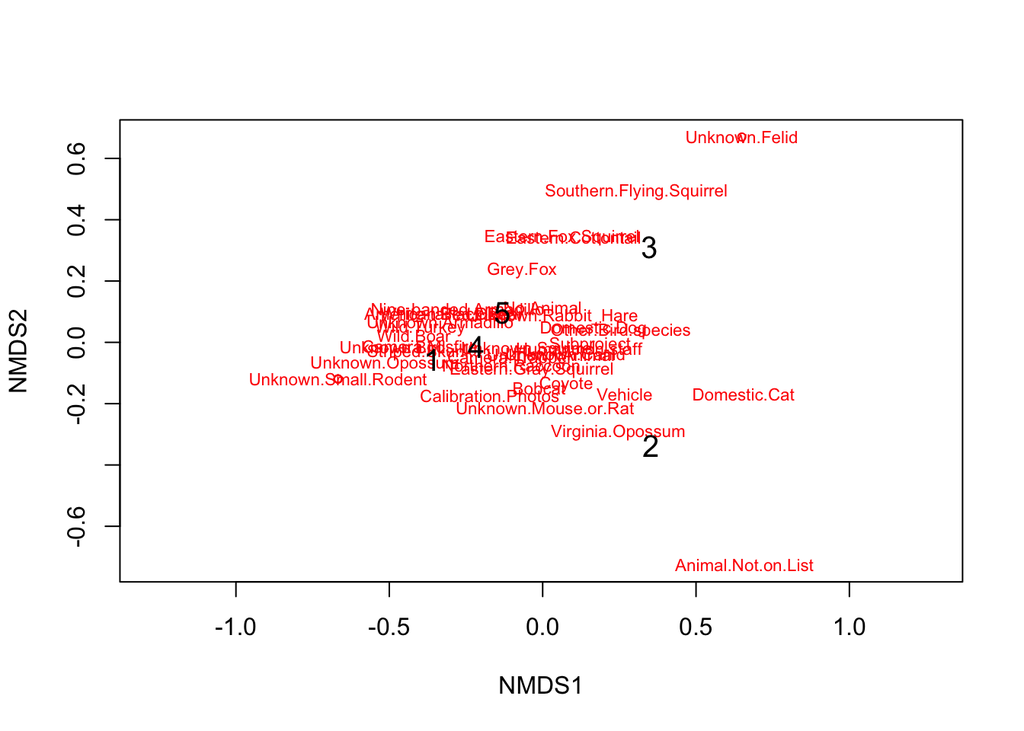

```r
ordiplot(cam_trap_NMDS,type="n")
orditorp(cam_trap_NMDS,display="species",col="red",air=0.01)
orditorp(cam_trap_NMDS,display="sites",cex=1.25,air=0.01)
```

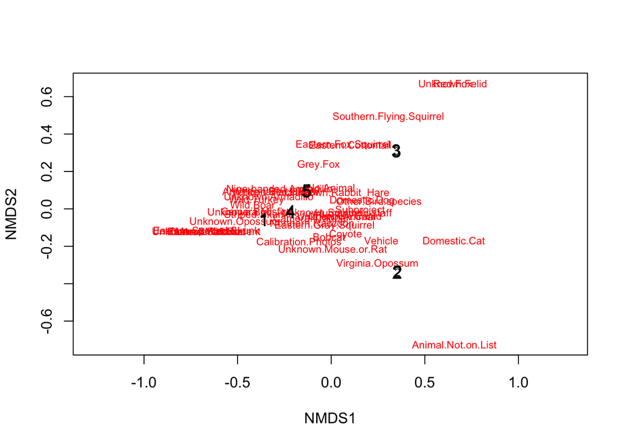

```r
cols <- c('red', 'black', 'blue', 'green', 'orange')
groups <- seq(length(speciesCount$Subproject))

ordiplot(cam_trap_NMDS,type="text")
orditorp(cam_trap_NMDS,display="sites",cex=1.25,air=0.01)
text(cam_trap_NMDS, display = 'sites')
```

#### Your Turn

```r
nop <- cam <- read_sheet("https://docs.google.com/spreadsheets/d/18yhZcaiYt6llg84eZYrNEewuLP3xaEyxYQQN__RQ3_4/edit?usp=sharing")
```

```
## ✔ Reading from "SnapshotUSA_Hammond".
```

```
## ✔ Range 'SnapshotUSA_Hammond'.
```